# On harmonic oscillator hazard functions

[F. Javier Rubio](https://sites.google.com/site/fjavierrubio67/) and J. Andres Christen

28 August, 2024

# Harmonic oscillator hazard function

This document provides codes and information about the *Damped Harmonic Oscillator* model proposed in Christen and Rubio (2024).

## The damped harmonic oscillator model

The harmonic oscillator hazard model is defined through the linear second order ODE:
$$\begin{equation}
h''(t) + 2 \eta w_0 h'(t) + w^2_0 (h(t) - h_b) = 0; \quad
h(0) = h_0, \quad h'(0) = r_0,
\label{eq:harmonic_osc}
\end{equation}$$
where $w_0 > 0$ is called the “natural frequency”, $\eta >0$ is the “damping coefficient”. The shift parameter, $h_b > 0$, represents the stability state or equilibrium level of the solution. The resulting model has closed-form hazard and cumulative hazard functions, facilitating likelihood and Bayesian inference on the parameters, as detailed in Christen and Rubio (2024).

The following R code presents an example from Christen and Rubio (2024) where we fit the damped harmonic oscillator model to the `rotterdam` data set from the R package `survival`. We present both Likelihood-based and Bayesian analyses.

# Data preparation

```r
#######################################################################################
# Data preparation
#######################################################################################

rm(list=ls())

# Required packages
library(deSolve)
library(survival)
library(ggplot2)
#library(devtools)
#install_github("FJRubio67/HazReg")
library(HazReg)
library(spBayes)
library(Rtwalk)
library(knitr)
library(bshazard)
```

```r
source("routinesHO.R")
```

```r
#--------------------------------------------------------------------------------------------------
#--------------------------------------------------------------------------------------------------
# Data preparation
#--------------------------------------------------------------------------------------------------
#--------------------------------------------------------------------------------------------------


head(rotterdam)
```

```
##      pid year age meno  size grade nodes pgr  er hormon chemo rtime recur dtime
## 1393   1 1992  74    1  <=20     3     0  35 291      0     0  1799     0  1799
## 1416   2 1984  79    1 20-50     3     0  36 611      0     0  2828     0  2828
## 2962   3 1983  44    0  <=20     2     0 138   0      0     0  6012     0  6012
## 1455   4 1985  70    1 20-50     3     0   0  12      0     0  2624     0  2624
## 977    5 1983  75    1  <=20     3     0 260 409      0     0  4915     0  4915
## 617    6 1983  52    0  <=20     3     0 139 303      0     0  5888     0  5888
##      death
## 1393     0
## 1416     0
## 2962     0
## 1455     0
## 977      0
## 617      0
```

```r
dim(rotterdam)
```

```
## [1] 2982   15
```

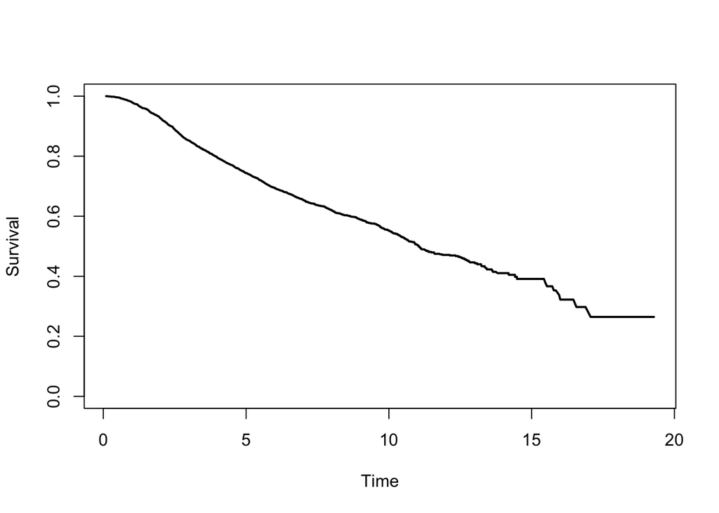

```r
# Kaplan-Meier estimator for the survival times
km <- survfit(Surv(rotterdam$dtime/365.24, rotterdam$death) ~ 1)

plot(km$time, km$surv, type = "l", col = "black", lwd = 2, lty = 1,
     ylim = c(0,1), xlab = "Time", ylab = "Survival")
```

```r
# New data frame: logical status, time in years, survival times sorted
df <- data.frame(time = rotterdam$dtime, status = rotterdam$death)
df$status <- as.logical(rotterdam$death)
df$time <- df$time/365.24

df <- df[order(df$time),]

# Required quantities
status <- as.logical(df$status)
t_obs <- df$time[status]
survtimes <- df$time
```

# Maximum Likelihood Analysis

## Weibull Model

```r
#==================================================================================================
# Maximum Likelihood Analysis
#==================================================================================================


#--------------------------------------------------------------------------------------------------
# Fitting a Weibull distribution
#--------------------------------------------------------------------------------------------------

# Initial value
initW <- c(0,0)

# Optimisation step
OPTW <- GHMLE(initW, survtimes, status, hstr = "baseline", dist = "Weibull", method = "nlminb", maxit = 10000)

MLEW <- exp(OPTW$OPT$par)

# Fitted Weibull hazard
fithw <- Vectorize(function(t) hweibull( t, exp(OPTW$OPT$par[1]), exp(OPTW$OPT$par[2]) ) )

# Fitted Weibull cumulative hazard
fitchw <- Vectorize(function(t) chweibull( t, exp(OPTW$OPT$par[1]), exp(OPTW$OPT$par[2]) ) )

# Fitted Weibull survival
fitsw <- Vectorize(function(t) exp(-chweibull( t, exp(OPTW$OPT$par[1]), exp(OPTW$OPT$par[2]) ) ))

# AIC
AICW <- 2*OPTW$OPT$objective + 2*length(OPTW$OPT$par)

# BIC
BICW <- 2*OPTW$OPT$objective + length(OPTW$OPT$par)*log(length(survtimes))
```

## The Power Generalised Weibull Model

```r
#==================================================================================================
# Maximum Likelihood Analysis
#==================================================================================================

#--------------------------------------------------------------------------------------------------
# Fitting a PGW distribution
#--------------------------------------------------------------------------------------------------

# Initial value
initPGW <- c(0,0,0)

# Optimisation step
OPTPGW <- GHMLE(initPGW, survtimes, status, hstr = "baseline", dist = "PGW",
                method = "nlminb", maxit = 10000)

MLEPGW <- exp(OPTPGW$OPT$par)

# Fitted Weibull hazard
fithpgw <- Vectorize(function(t) hpgw( t, MLEPGW[1], MLEPGW[2], MLEPGW[3] ) )

# Fitted Weibull cumulative hazard
fitchpgw <- Vectorize(function(t) chpgw( t, MLEPGW[1], MLEPGW[2], MLEPGW[3] ) )

# Fitted Weibull survival
fitspgw <- Vectorize(function(t) exp(-chpgw( t, MLEPGW[1], MLEPGW[2], MLEPGW[3] ) ))

# AIC
AICPGW <- 2*OPTPGW$OPT$objective + 2*length(OPTPGW$OPT$par)

# BIC
BICPGW <- 2*OPTPGW$OPT$objective + length(OPTPGW$OPT$par)*log(length(survtimes))
```

## The Damped Harmonic Oscillator Model

```r
#==================================================================================================
# MLE Analysis
#==================================================================================================

#--------------------------------------------------------------------------------------------------
# Harmonic Oscillator model for the hazard function: Solver solution
#--------------------------------------------------------------------------------------------------

# Initial conditions

# Survival at time 0
S0 <- 1
# Survival at 1 month
St <- 0.999
# Survival at 2 months
Stt <- 0.998
# dt = 1 month
dt <- 1/12

# Approximation of the initial conditions
Sp <- -(St-S0)/dt
Spp <- (Stt - 2*St + S0)/(dt^2)

h00 <- Sp/St
r00 <- h00^2 - Spp/St

# Initial point
initHO <- c(0.1,0,0)

# Optimisation step
OPTHO <- optim(initHO, log_likHO, control = list(maxit = 1000))
OPTHO
```

```
## $par
## [1] -0.8421869  0.2711340 -2.7299280
##
## $value
## [1] 4778.518
##
## $counts
## function gradient
##      194       NA
##
## $convergence
## [1] 0
##
## $message
## NULL
```

```r
MLEHO <- exp(OPTHO$par)

# AIC
AICHO <- 2*OPTHO$value + 2*length(OPTHO$par)

# BIC
BICHO <- 2*OPTHO$value + length(OPTHO$par)*log(length(survtimes))
```

## Comparison

```r
# AIC comparison
AICs <- c(AICW, AICPGW, AICHO)

AICs
```

```
## [1] 9638.298 9572.033 9563.036
```

```r
# Best model (Harmonic oscillator)
which.min(AICs)
```

```
## [1] 3
```

```r
# BIC comparison
BICs <- c(BICW, BICPGW, BICHO)

BICs
```

```
## [1] 9650.299 9590.034 9581.037
```

```r
# Best model (Harmonic oscillator)
which.min(BICs)
```

```
## [1] 3
```

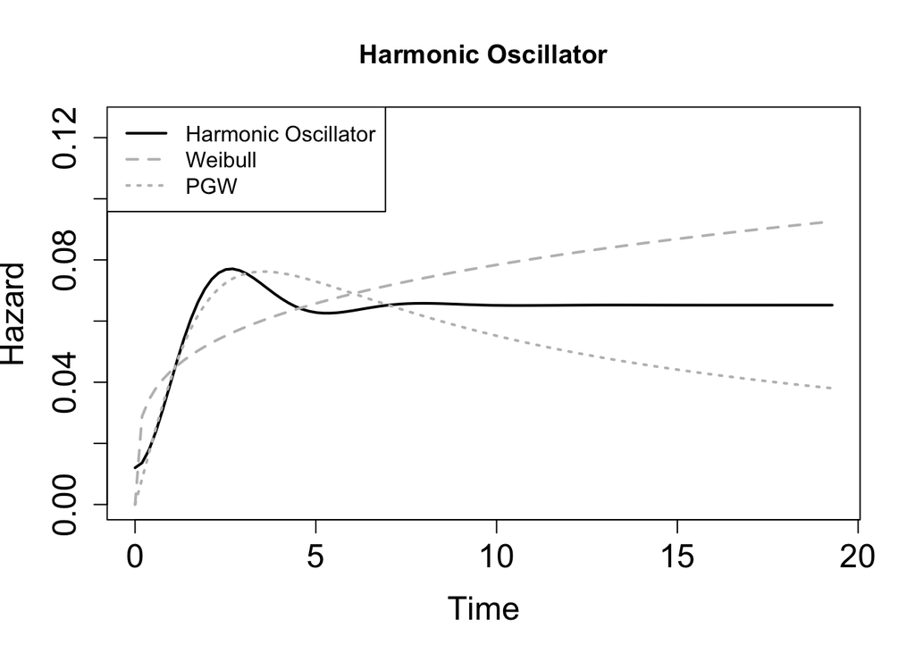

```r
# Fitted hazard, cumulative hazard, and survival
fithHO <- Vectorize(function(t) hHO(t,exp(OPTHO$par[1]), exp(OPTHO$par[2]), exp(OPTHO$par[3]), h00, r00))
fitchHO <- Vectorize(function(t) chHO(t,exp(OPTHO$par[1]), exp(OPTHO$par[2]), exp(OPTHO$par[3]), h00, r00))
fitsHO <- Vectorize(function(t) exp(-chHO(t,exp(OPTHO$par[1]), exp(OPTHO$par[2]), exp(OPTHO$par[3]), h00, r00)))

# Comparison: hazard functions
curve(fithHO, 0, max(survtimes), xlim= c(0,max(survtimes)), ylim = c(0,0.125), lwd = 2,
     xlab = "Time", ylab = "Hazard", main = "Harmonic Oscillator", cex.axis = 1.5, cex.lab = 1.5)
curve(fithw, 0, max(survtimes), lwd= 2, lty = 2, col = "gray", add = TRUE)
curve(fithpgw, 0, max(survtimes), lwd= 2, lty = 3, col = "gray", add = TRUE)
legend("topleft", legend = c("Harmonic Oscillator","Weibull", "PGW"), lty = c(1,2,3),
       lwd = c(2,2,2), col = c("black","gray","gray"))
```

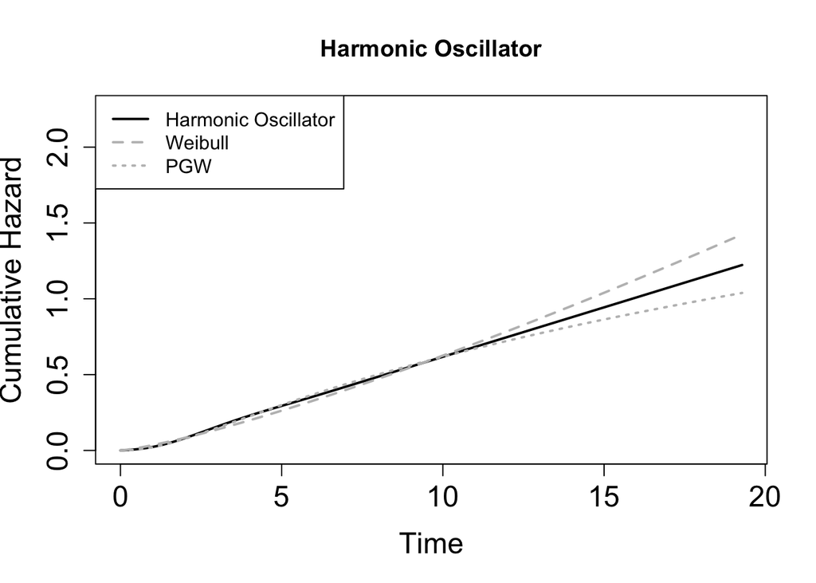

```r
# Comparison: cumulative hazard functions
curve(fitchHO, 0, max(survtimes), xlim = c(0,max(survtimes)), ylim = c(0,2.25),  lwd = 2,
     xlab = "Time", ylab = "Cumulative Hazard", main = "Harmonic Oscillator", cex.axis = 1.5, cex.lab = 1.5)
curve(fitchw, 0, max(survtimes), lwd= 2, lty = 2, col = "gray", add = TRUE)
curve(fitchpgw, 0, max(survtimes), lwd= 2, lty = 3, col = "gray", add = TRUE)
legend("topleft", legend = c("Harmonic Oscillator","Weibull","PGW"), lty = c(1,2,3),
       lwd = c(2,2,2), col = c("black","gray","gray"))
```

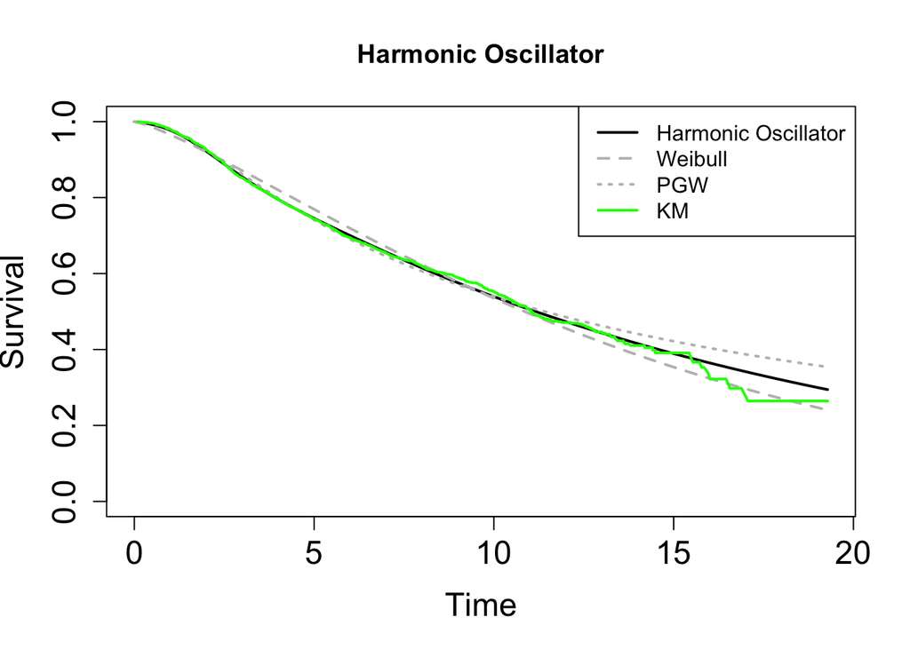

```r
# Comparison: survival functions
curve(fitsHO, 0, max(survtimes), xlim = c(0,max(survtimes)), ylim = c(0,1), lwd = 2,
     xlab = "Time", ylab = "Survival", main = "Harmonic Oscillator", cex.axis = 1.5, cex.lab = 1.5)
curve(fitsw, 0, max(survtimes), lwd= 2, lty = 2, col = "gray", add = TRUE)
curve(fitspgw, 0, max(survtimes), lwd= 2, lty = 3, col = "gray", add = TRUE)
points(km$time, km$surv, type = "l", col = "green", lwd = 2, lty = 1)
legend("topright", legend = c("Harmonic Oscillator","Weibull","PGW","KM"), lty = c(1,2,3,1),
       lwd = c(2,2,2,2), col = c("black","gray","gray","green"))
```

# Bayesian Analysis

## Weibull

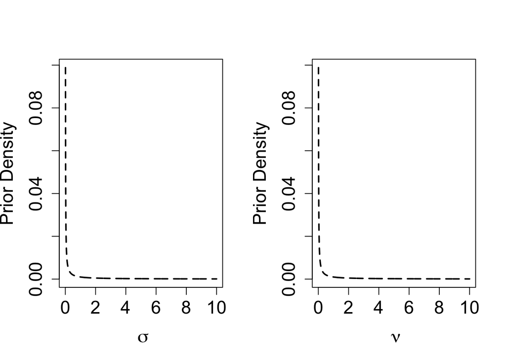

```r
#==================================================================================================
# Bayesian Analysis
#==================================================================================================

#--------------------------------------------------------------------------------------------------
# Priors
#--------------------------------------------------------------------------------------------------

par(mfrow = c(1,2))
p_sigmaW <- Vectorize(function(t) dgamma(t, shape = 0.001, scale = 1/0.001))
curve(p_sigmaW,0,10, n = 1000, xlab = ~sigma, ylab = "Prior Density",
      cex.axis = 1.5, cex.lab = 1.5, lwd = 2, lty = 2)

p_nuW <- Vectorize(function(t) dgamma(t, shape = 0.001, scale = 1/0.001))
curve(p_nuW,0,10, n = 1000, xlab = ~nu, ylab = "Prior Density",
      cex.axis = 1.5, cex.lab = 1.5, lwd = 2, lty = 2)
```

```r
par(mfrow = c(1,1))

#--------------------------------------------------------------------------------------------------
# Weibull model for the hazard function
#--------------------------------------------------------------------------------------------------

# Support
SupportW <- function(x) {   TRUE }

# Random initial points
X0W <- function(x) { OPTW$OPT$par + runif(2,-0.01,0.01) }

# twalk for analytic solution
set.seed(1234)
infoW <- Runtwalk( dim=2,  Tr=110000,  Obj=log_postW, Supp=SupportW,
                   x0=X0W(), xp0=X0W(), PlotLogPost = FALSE)
```

```
## This is the twalk for R.
## Evaluating the objective density at initial values.
## Opening 6 X 110001 matrix to save output.  Sampling (no graphics mode).
```

```r
# Posterior sample after burn-in and thinning
ind=seq(10000,110000,100)

# Summaries
summW <- apply(exp(infoW$output[ind,]),2,summary)
colnames(summW) <- c("sigma","nu")
kable(summW, digits = 3)
```

|  | sigma | nu |
| --- | --- | --- |
| Min. | 13.435 | 1.164 |
| 1st Qu. | 14.290 | 1.233 |
| Median | 14.555 | 1.253 |
| Mean | 14.555 | 1.254 |
| 3rd Qu. | 14.804 | 1.275 |
| Max. | 15.738 | 1.363 |

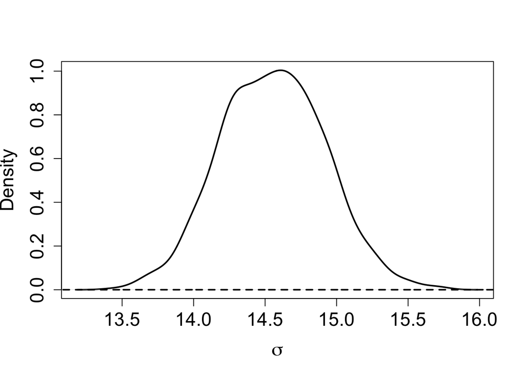

```r
# KDEs
sigmapW <- exp(infoW$output[,1][ind])
nupW <- exp(infoW$output[,2][ind])

plot(density(sigmapW), main = "", xlab = expression(sigma), ylab = "Density",
     cex.axis = 1.5, cex.lab = 1.5, lwd = 2)
curve(p_sigmaW,13,17, n = 1000, xlab = ~lambda, ylab = "Prior Density",
      cex.axis = 1.5, cex.lab = 1.5, lwd = 2, lty = 2, add = TRUE)
```

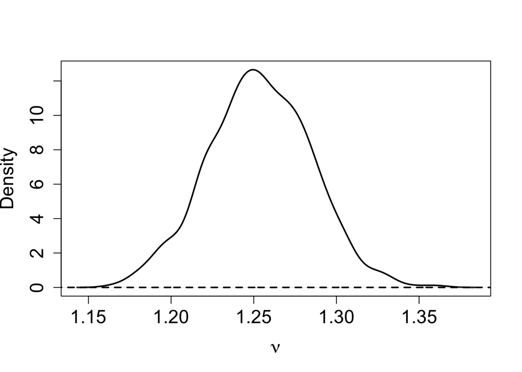

```r
plot(density(nupW), main = "", xlab = expression(nu), ylab = "Density",
     cex.axis = 1.5, cex.lab = 1.5, lwd = 2)
curve(p_nuW,1.1,1.5, n = 1000, xlab = ~kappa, ylab = "Prior Density",
      cex.axis = 1.5, cex.lab = 1.5, lwd = 2, lty = 2, add = TRUE)
```

## The Power Generalised Weibull Model

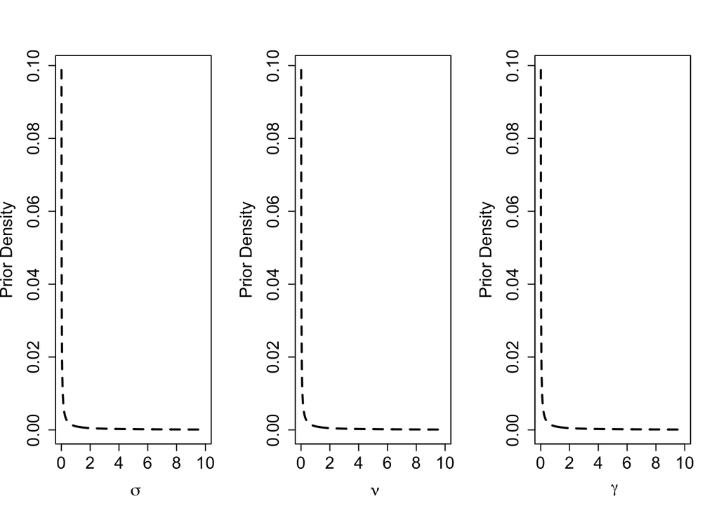

```r
#==================================================================================================
# Bayesian Analysis
#==================================================================================================

#--------------------------------------------------------------------------------------------------
# Priors
#--------------------------------------------------------------------------------------------------

par(mfrow = c(1,3))
p_sigmaPGW <- Vectorize(function(t) dgamma(t, shape = 0.001, scale = 1/0.001))
curve(p_sigmaPGW,0,10, n = 1000, xlab = ~sigma, ylab = "Prior Density",
      cex.axis = 1.5, cex.lab = 1.5, lwd = 2, lty = 2)

p_nuPGW <- Vectorize(function(t) dgamma(t, shape = 0.001, scale = 1/0.001))
curve(p_nuPGW,0,10, n = 1000, xlab = ~nu, ylab = "Prior Density",
      cex.axis = 1.5, cex.lab = 1.5, lwd = 2, lty = 2)

p_gammaPGW <- Vectorize(function(t) dgamma(t, shape = 0.001, scale = 1/0.001))
curve(p_gammaPGW,0,10, n = 1000, xlab = ~gamma, ylab = "Prior Density",
      cex.axis = 1.5, cex.lab = 1.5, lwd = 2, lty = 2)
```

```r
par(mfrow = c(1,1))

#--------------------------------------------------------------------------------------------------
# Weibull model for the hazard function
#--------------------------------------------------------------------------------------------------

# Support
SupportPGW <- function(x) {   TRUE }

# Random initial points
X0PGW <- function(x) { OPTPGW$OPT$par + runif(3,-0.01,0.01) }


# twalk for analytic solution
set.seed(1234)
infoPGW <- Runtwalk( dim=3,  Tr=110000,  Obj=log_postPGW, Supp=SupportPGW,
                     x0=X0PGW(), xp0=X0PGW(), PlotLogPost = FALSE)
```

```
## This is the twalk for R.
## Evaluating the objective density at initial values.
## Opening 8 X 110001 matrix to save output.  Sampling (no graphics mode).
```

```r
# Posterior sample after burn-in and thinning
ind=seq(10000,110000,100)

# Summaries
summPGW <- apply(exp(infoPGW$output[ind,]),2,summary)
colnames(summPGW) <- c("sigma","nu","gamma")
kable(summPGW, digits = 3)
```

|  | sigma | nu | gamma |
| --- | --- | --- | --- |
| Min. | 2.187 | 1.653 | 3.531 |
| 1st Qu. | 2.637 | 1.939 | 5.063 |
| Median | 2.808 | 2.018 | 5.469 |
| Mean | 2.832 | 2.025 | 5.509 |
| 3rd Qu. | 2.990 | 2.110 | 5.982 |
| Max. | 4.156 | 2.506 | 7.697 |

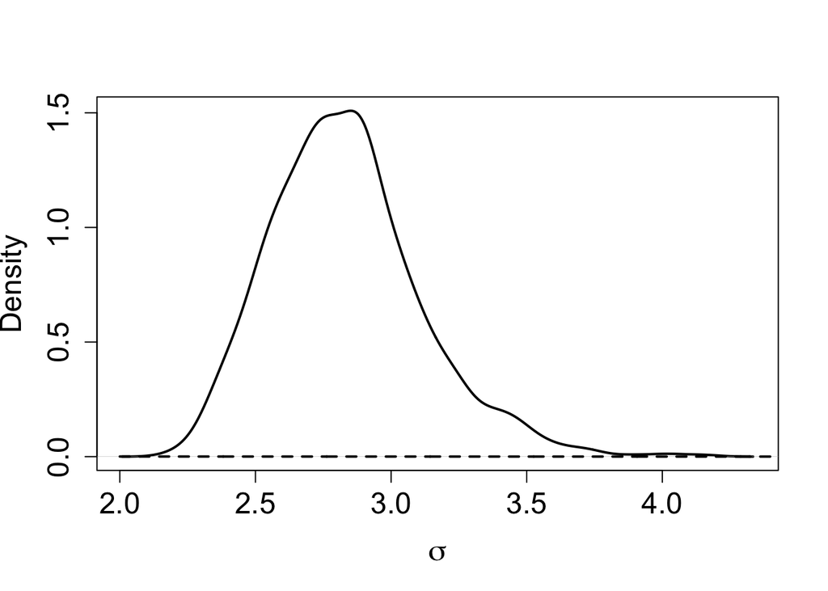

```r
# KDEs
sigmapPGW <- exp(infoPGW$output[,1][ind])
nupPGW <- exp(infoPGW$output[,2][ind])
gammapPGW <- exp(infoPGW$output[,3][ind])

plot(density(sigmapPGW), main = "", xlab = expression(sigma), ylab = "Density",
     cex.axis = 1.5, cex.lab = 1.5, lwd = 2)
curve(p_sigmaPGW,2,5, n = 1000, xlab = ~lambda, ylab = "Prior Density",
      cex.axis = 1.5, cex.lab = 1.5, lwd = 2, lty = 2, add = TRUE)
```

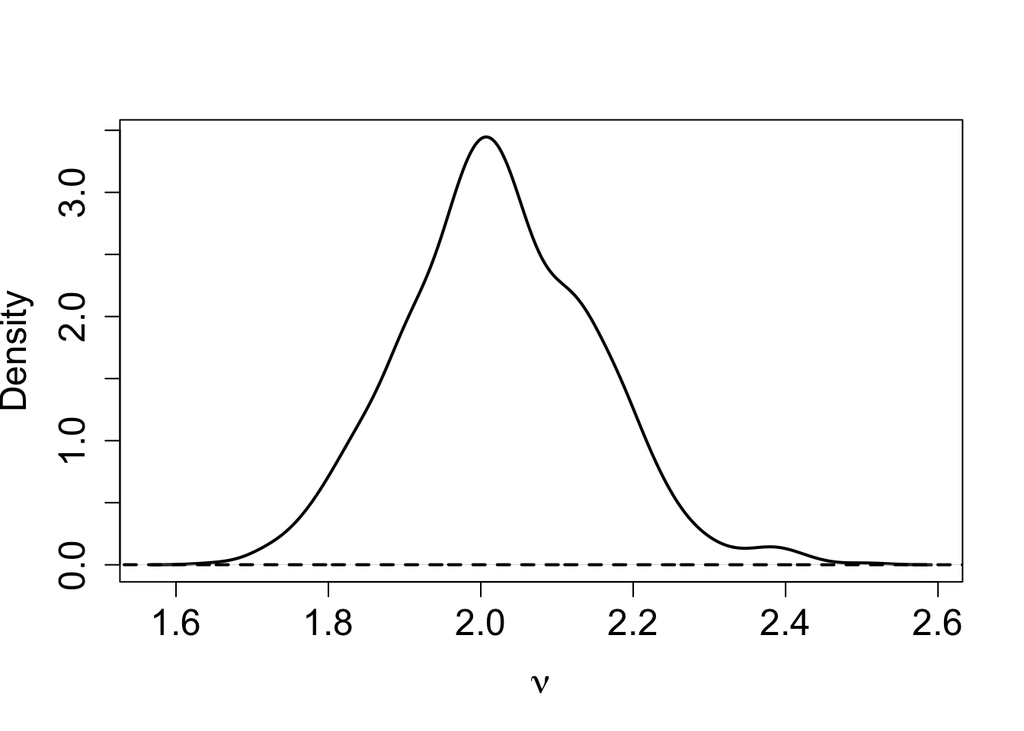

```r
plot(density(nupPGW), main = "", xlab = expression(nu), ylab = "Density",
     cex.axis = 1.5, cex.lab = 1.5, lwd = 2)
curve(p_nuPGW,1.5,2.7, n = 1000, xlab = ~kappa, ylab = "Prior Density",
      cex.axis = 1.5, cex.lab = 1.5, lwd = 2, lty = 2, add = TRUE)
```

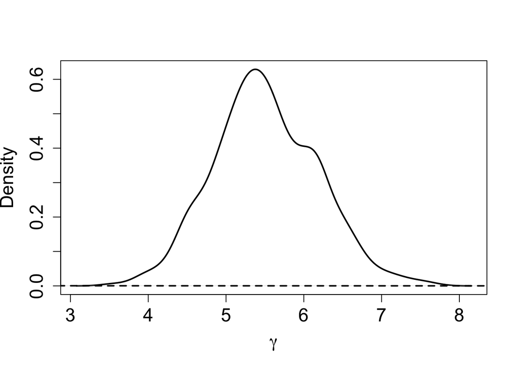

```r
plot(density(gammapPGW), main = "", xlab = expression(gamma), ylab = "Density",
     cex.axis = 1.5, cex.lab = 1.5, lwd = 2)
curve(p_gammaPGW,0,15, cex.lab = 1.5, lwd = 2, lty = 2, add = TRUE)
```

## The Harmonic Oscillator hazard Model

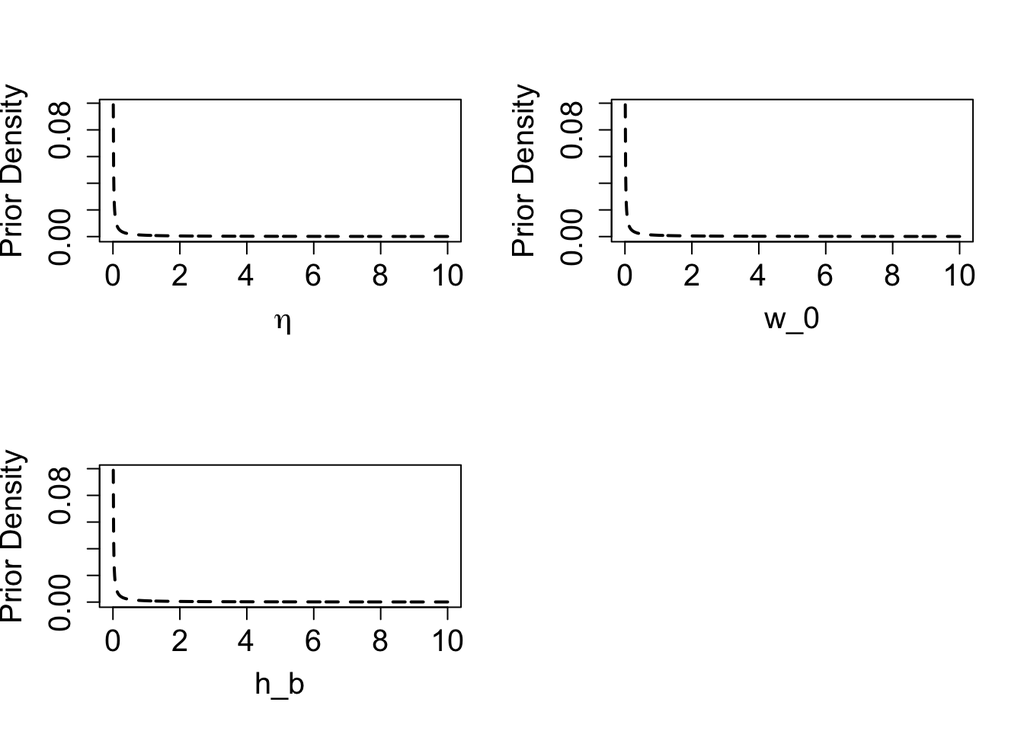

```r
#==================================================================================================
# Bayesian Analysis
#==================================================================================================

#--------------------------------------------------------------------------------------------------
# Priors
#--------------------------------------------------------------------------------------------------

par(mfrow = c(2,2))
p_eta <- Vectorize(function(t) dgamma(t, shape = 0.001, scale = 1/0.001))
curve(p_eta,0,10, n = 1000, xlab = ~eta, ylab = "Prior Density",
      cex.axis = 1.5, cex.lab = 1.5, lwd = 2, lty = 2)

p_w0 <- Vectorize(function(t) dgamma(t, shape = 0.001, scale = 1/0.001))
curve(p_w0,0,10, n = 1000, xlab = expression(w_0), ylab = "Prior Density",
      cex.axis = 1.5, cex.lab = 1.5, lwd = 2, lty = 2)

p_hb <- Vectorize(function(t) dgamma(t, shape = 0.001, scale = 1/0.001))
curve(p_hb,0,10, n = 1000, xlab = expression(h_b), ylab = "Prior Density",
      cex.axis = 1.5, cex.lab = 1.5, lwd = 2, lty = 2)


par(mfrow = c(1,1))
```

```r
#--------------------------------------------------------------------------------------------------
# Posterior sampling
#--------------------------------------------------------------------------------------------------


n.batch <- 1100
batch.length <- 100

lp <- function(par) -log_postHO(par)

inits <- OPTHO$par
```

```r
set.seed(1234)
infoHO <- adaptMetropGibbs(ltd=lp, starting=inits, accept.rate=0.44, batch=n.batch,
                           batch.length=batch.length, report=100, verbose=FALSE)
```

```r
chainHO <- infoHO$p.theta.samples[,1:3]

# Burning and thinning the chain
burn <- 1e4
thin <- 100
NS <- n.batch*batch.length
ind <- seq(burn,NS,thin)



# Summaries
summHO <- apply(exp(chainHO[ind,1:3]),2,summary)
colnames(summHO) <- c("eta","w_0","h_b")
kable(summHO, digits = 3)
```

|  | eta | w_0 | h_b |
| --- | --- | --- | --- |
| Min. | 0.253 | 0.977 | 0.059 |
| 1st Qu. | 0.389 | 1.251 | 0.064 |
| Median | 0.436 | 1.327 | 0.065 |
| Mean | 0.447 | 1.333 | 0.065 |
| 3rd Qu. | 0.494 | 1.408 | 0.067 |
| Max. | 0.746 | 1.809 | 0.074 |

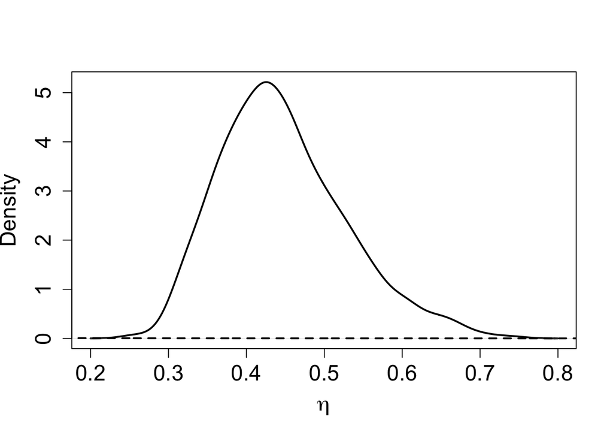

```r
# KDEs
etap <- exp(chainHO[,1][ind])
w0p <- exp(chainHO[,2][ind])
hbp <- exp(chainHO[,3][ind])


plot(density(etap), main = "", xlab = expression(eta), ylab = "Density",
     cex.axis = 1.5, cex.lab = 1.5, lwd = 2)
curve(p_eta,0,1, n = 1000, xlab = ~lambda, ylab = "Prior Density",
      cex.axis = 1.5, cex.lab = 1.5, lwd = 2, lty = 2, add = TRUE)
```

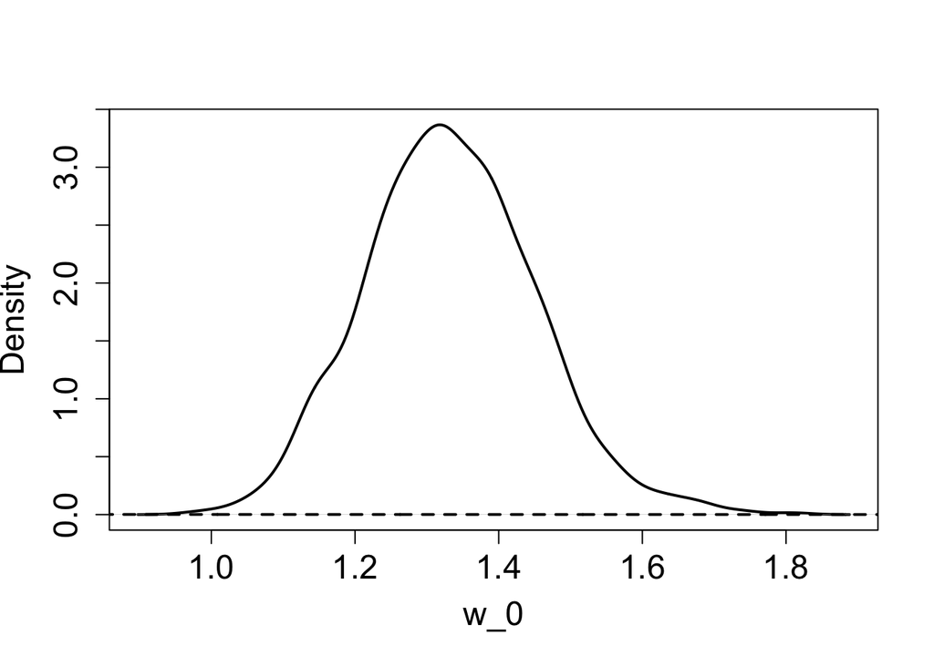

```r
plot(density(w0p), main = "", xlab = expression(w_0), ylab = "Density",
     cex.axis = 1.5, cex.lab = 1.5, lwd = 2)
curve(p_w0,0.5,2.5, n = 1000, xlab = expression(w_0), ylab = "Prior Density",
      cex.axis = 1.5, cex.lab = 1.5, lwd = 2, lty = 2, add = TRUE)
```

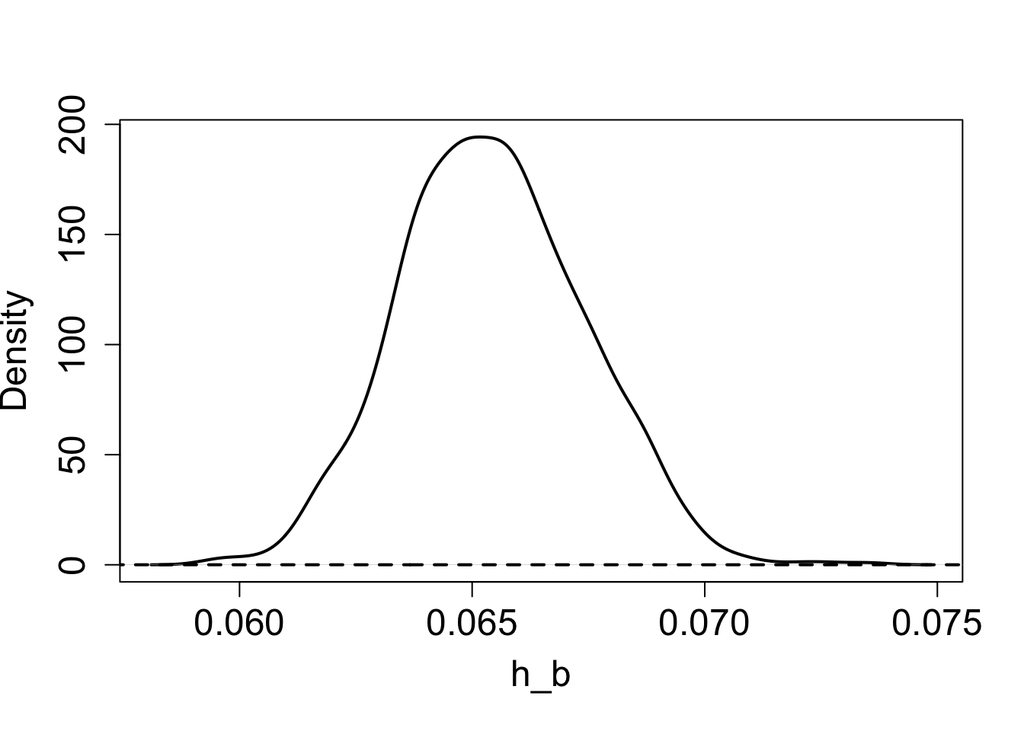

```r
plot(density(hbp), main = "", xlab = expression(h_b), ylab = "Density",
     cex.axis = 1.5, cex.lab = 1.5, lwd = 2)
curve(p_hb,0,0.1, n = 1000, xlab = expression(h_b), ylab = "Prior Density",
      cex.axis = 1.5, cex.lab = 1.5, lwd = 2, lty = 2, add = TRUE)
```

## Predictive Hazard functions

```r
#---------------------------------------------------------------------------------------
# Predictive Hazard functions
#---------------------------------------------------------------------------------------

# Predictive Weibull hazard
predhW <- Vectorize(function(t){
  num <- den <- temp <- vector()
  for(i in 1:length(ind)){
    num[i] <- exp(-chweibull( t, sigmapW[i], nupW[i]))*hweibull( t, sigmapW[i], nupW[i])
    den[i] <- exp(-chweibull( t, sigmapW[i], nupW[i]))
  }
  return(mean(num)/mean(den))
})

# Predictive PGW
predhPGW <- Vectorize(function(t){
  num <- den <- temp <- vector()
  for(i in 1:length(ind)) num[i] <- exp(-chpgw( t, sigmapPGW[i], nupPGW[i], gammapPGW[i]))*
      hpgw( t, sigmapPGW[i], nupPGW[i], gammapPGW[i])
  for(i in 1:length(ind)) den[i] <- exp(-chpgw( t, sigmapPGW[i], nupPGW[i], gammapPGW[i]))
  return(mean(num)/mean(den))
})



# Creating the credible envelopes
tvec <- seq(0,20,by = 0.01)
ntvec <- length(tvec)

# Weibull
hCIW <- matrix(0, ncol = ntvec, nrow = length(ind))

for(j in 1:length(ind)){
  for(k in 1:ntvec){
    hCIW[j,k ] <- hweibull( tvec[k],sigmapW[j], nupW[j])
  }
}

hW <-  predhW(tvec)


hCIWL <- apply(hCIW, 2, ql)
hCIWU <- apply(hCIW, 2, qu)

# PGW
hCIPGW <- matrix(0, ncol = ntvec, nrow = length(ind))

for(j in 1:length(ind)){
  for(k in 1:ntvec){
    hCIPGW[j,k ] <- hpgw( tvec[k],sigmapPGW[j], nupPGW[j], gammapPGW[j])
  }
}

hPGWs <-  predhPGW(tvec)

hCIPGWL <- apply(hCIPGW, 2, ql)
hCIPGWU <- apply(hCIPGW, 2, qu)

# Harmonic Oscillator

# Predictive HO hazard
predhHO <- Vectorize(function(t){
  num <- den <- temp <- vector()
  for(i in 1:length(ind)){
    chi <- chHO( t, etap[i], w0p[i], hbp[i], h00, r00 )
    num[i] <- exp(-chi)*hHO( t, etap[i], w0p[i], hbp[i], h00, r00 )
    den[i] <- exp(-chi)
  }
  return(mean(num)/mean(den))
})


# Creating the credible envelopes
tvec <- seq(0,20,by = 0.01)
ntvec <- length(tvec)

hHOs <-  predhHO(tvec)

hCIHO<- matrix(0, ncol = ntvec, nrow = length(ind))

for(j in 1:length(ind)){
  for(k in 1:ntvec){
    hCIHO[j,k ] <- hHO( tvec[k],etap[j], w0p[j], hbp[j], h00, r00)
  }
}

hCIHOL <- apply(hCIHO, 2, ql)
hCIHOU <- apply(hCIHO, 2, qu)

# Splines model
fit <- bshazard(Surv(df$time, df$status) ~ 1, data = df, nbin = 100, degree = 3, verbose = FALSE)
```

```
## NOTE: entry.status has been set to 0 for all.
```

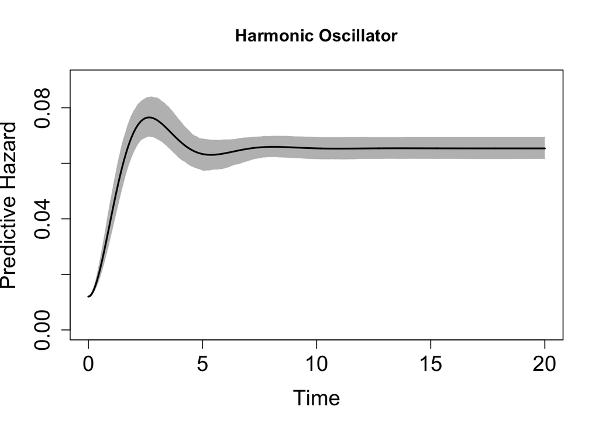

```r
# Predictive hazard plot
curve(predhHO, 0, 20, n = 1000, xlab = "Time", ylab = "Predictive Hazard",
      main = "Harmonic Oscillator",
      cex.axis = 1.5, cex.lab = 1.5, lwd =2, lty = 1, ylim = c(0,0.09))

points(tvec,  hCIHOL, col = "gray", type = "l")
points(tvec,  hCIHOU, col = "gray", type = "l")
polygon(c(tvec, rev(tvec)), c(hCIHOL[order(tvec)], rev(hCIHOU[order(tvec)])),
        col = "gray", border = NA)
curve(predhHO, 0, 20, n = 1000, xlab = "Time", ylab = "Predictive Hazard",
      cex.axis = 1.5, cex.lab = 1.5, lwd =2, lty = 1, ylim = c(0,0.08), add = TRUE)
```

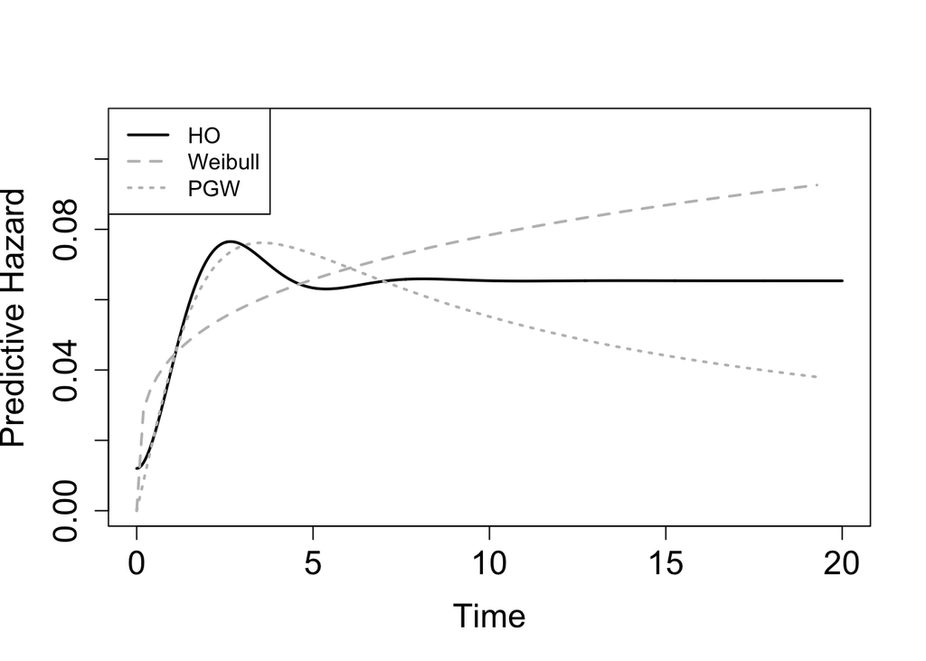

```r
# Comparison with Weibull and PGW
#pdf("predhaz.pdf", height = 6, width = 8)
curve(predhHO, 0, 20, n = 1000, xlab = "Time", ylab = "Predictive Hazard",
      cex.axis = 1.5, cex.lab = 1.5, lwd =2, lty = 1, ylim = c(0,0.11))
curve(fithw, 0, max(survtimes), lwd= 2, lty = 2, col = "gray", add = TRUE)
curve(fithpgw, 0, max(survtimes), lwd= 2, lty = 3, col = "gray", add = TRUE)
legend("topleft", legend = c("HO","Weibull", "PGW"), lty = c(1,2,3),
       lwd = c(2,2,2), col = c("black","gray","gray"))
```

```r
#dev.off()
```

## Predictive Survival functions

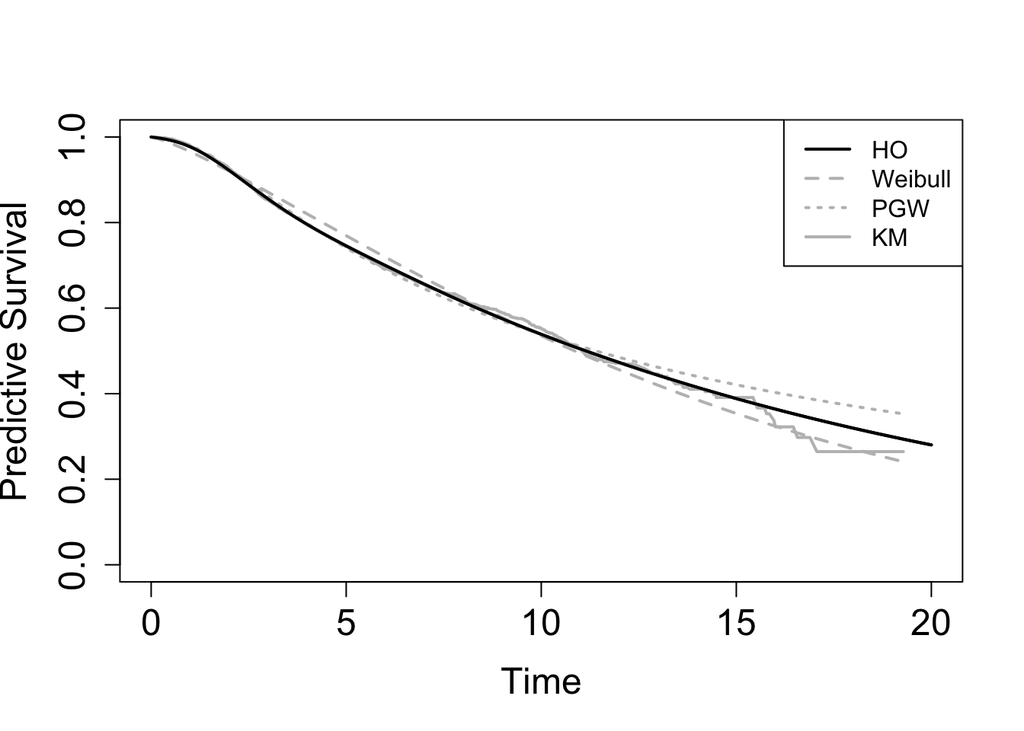

```r
#---------------------------------------------------------------------------------------
# Predictive Survival functions
#---------------------------------------------------------------------------------------

# Predictive Weibull survival
predsW <- Vectorize(function(t){
  temp <- vector()
  for(i in 1:length(ind)) temp[i] <- exp(-chweibull(t,sigmapW[i], nupW[i]) )
  return(mean(temp))
})

# Predictive PGW survival
predsPGW <- Vectorize(function(t){
  temp <- vector()
  for(i in 1:length(ind)) temp[i] <- exp(-chpgw( t,sigmapPGW[i], nupPGW[i], gammapPGW[i]) )
  return(mean(temp))
})


# Predictive HO Survival
predsHO <- Vectorize(function(t){
  temp <- vector()
  for(i in 1:length(ind)){
    temp[i] <- exp(-chHO( t, etap[i], w0p[i], hbp[i], h00, r00 ))
  }
  return(mean(temp))
})

# Comparison: survival functions
#pdf("predsurv.pdf", height = 6, width = 8)
curve(predsHO, 0, 20, n = 1000, xlab = "Time", ylab = "Predictive Survival",
      cex.axis = 1.5, cex.lab = 1.5, lwd =2, lty = 1, ylim = c(0,1))
curve(predsW, 0, max(survtimes), lwd= 2, lty = 2, col = "gray", add = TRUE)
curve(predsPGW, 0, max(survtimes), lwd= 2, lty = 3, col = "gray", add = TRUE)
points(km$time, km$surv, type = "l", col = "gray", lwd = 2, lty = 1)
curve(predsHO, 0, 20, n = 1000, xlab = "Time", ylab = "Predictive Survival",
      cex.axis = 1.5, cex.lab = 1.5, lwd =2, lty = 1, ylim = c(0,1),add=TRUE)
legend("topright", legend = c("HO","Weibull","PGW","KM"), lty = c(1,2,3,1),
       lwd = c(2,2,2,2), col = c("black","gray","gray","gray"))
```

```r
#dev.off()
```

# Comparison with a spline-based estimator

Now, we present a comparison of the estimated hazard function with that obtained with the R command `bshazard` from the R package `bshazard`. This estimator is based on B-Splines. See [bshazard: Nonparametric Smoothing of the Hazard Function](https://cran.r-project.org/package=bshazard).

```r
# fitting the estimator
fit <- bshazard(Surv(df$time, df$status) ~ 1, data = df, nbin = 100, degree = 3, verbose = FALSE)
```

```
## NOTE: entry.status has been set to 0 for all.
```

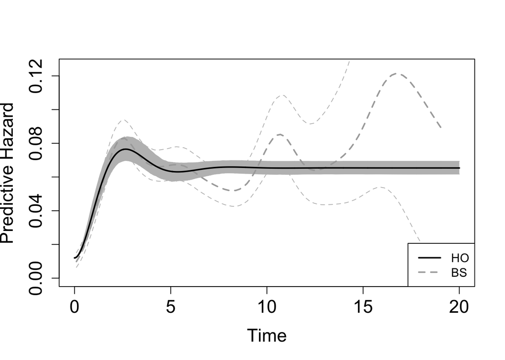

```r
# Hazard
plot(tvec,  hHOs, type = "l", xlab = "Time", ylab = "Predictive Hazard",
       cex.axis = 1.5, cex.lab = 1.5, lwd =2, lty = 1, ylim = c(0,0.125))
points(tvec,  hCIHOL, col = "gray", type = "l")
points(tvec,  hCIHOU, col = "gray", type = "l")
polygon(c(tvec, rev(tvec)), c(hCIHOL[order(tvec)], rev(hCIHOU[order(tvec)])),
        col = "gray", border = NA)
points(fit$time, fit$hazard, type='l', lwd = 2, lty = 2, ylim = c(0,0.25), col = "darkgray")
lines(fit$time, fit$lower.ci, lty = 2, lwd = 1, col = "gray")
lines(fit$time, fit$upper.ci, lty = 2, lwd = 1, col = "gray")
points(tvec,  hHOs, type = "l", xlab = "Time", ylab = "Predictive Hazard",
       cex.axis = 1.5, cex.lab = 1.5, lwd =2, lty = 1)
legend("bottomright", legend = c("HO", "BS"), lty = c(1,2),
       lwd = c(2,2), col = c("black","darkgray"))
```

Christen, J. A., and F. J. Rubio. 2024. “On Harmonic Oscillator Hazard Functions.” *arXiv Preprint*.